# Assignment 3: Verify the Claim - Poverty Change in Philadelphia

- Show All Code
- Hide All Code
- View Source

Testing a published claim about neighborhood change against the data behind it

Author

Leo Leung

Published

September 24, 2026

## The claim

This report checks the claim identified in my draft from Alfred Lubrano’s [2018 WHYY / Philadelphia Inquirer article](https://whyy.org/articles/new-census-figures-on-philly-neighborhoods-show-inequality-high-numbers-of-whites-living-in-poverty/): Eastwick’s poverty rate rose from 12% in 2006–2010 to 26% in 2013–2017, described as the largest neighborhood increase. This would be a **14-percentage-point increase**. Following the assignment, I examine Philadelphia census tracts. The assignment explains that the article does not publish its tract-to-neighborhood groupings, so this analysis can test the broader pattern of change but cannot reproduce Eastwick’s boundaries or ranking.

## Part 1 — Reconstruct

I use **B17001_002**, the number of people whose income in the past 12 months was below the poverty level, divided by **B17001_001**, the population for whom poverty status is determined. The denominator is the population covered by this poverty table, rather than the entire population from a separate table. I use the same variables in both periods so that the rates measure the same thing. The Week 3 notes identify B17001_002 as a poverty count; I adapt the practice script’s `moe_prop()` calculation to this table. The `E` columns contain estimates and the `M` columns contain their margins of error.

I request `survey = "acs5"` with `year = 2010` and `year = 2017`, which represent **2006–2010** and **2013–2017**. Five-year estimates are available for tracts, and these are the periods specified in the assignment. The periods **do not overlap**: they share no survey years. I use the class method that treats their sampling errors as independent. I assume B17001 is an appropriate reconstruction of the article’s poverty measure and that matching tract GEOIDs represent comparable areas. A matching identifier alone does not verify unchanged boundaries. I do not assign neighborhood names to tracts or average tract rates to reconstruct a neighborhood.

```r
acs_2006_2010 <- get_acs(
  geography = "tract",
  variables = c(
    total_pop = "B17001_001",
    total_poverty = "B17001_002"
  ),
  state = "PA",
  county = "Philadelphia",
  year = 2010,
  survey = "acs5",
  output = "wide"
)

acs_2013_2017 <- get_acs(
  geography = "tract",
  variables = c(
    total_pop = "B17001_001",
    total_poverty = "B17001_002"
  ),
  state = "PA",
  county = "Philadelphia",
  year = 2017,
  survey = "acs5",
  output = "wide"
)
```

## Part 2 — Test

### Calculate rates and investigate missing values

I combine the two downloads with a period label, then apply the same calculation to every tract-period row. Multiplying both the proportion and its MOE by 100 expresses the rate as a percentage and the MOE in percentage points. I check the original counts before calculating rates: a zero denominator makes a rate undefined, rather than making it a zero-poverty tract. Missing or invalid inputs remain unavailable.

```r
poverty_rates <- bind_rows(
  acs_2006_2010 %>% mutate(period = "2006-2010"),
  acs_2013_2017 %>% mutate(period = "2013-2017")
) %>%
  mutate(
    input_status = case_when(
      is.na(total_popE) | is.na(total_povertyE) |
        is.na(total_popM) | is.na(total_povertyM) ~ "Missing count or MOE",
      total_popE == 0 ~ "Zero poverty-universe population",
      total_popE < 0 | total_povertyE < 0 |
        total_povertyE > total_popE |
        total_popM < 0 | total_povertyM < 0 ~ "Invalid count or MOE",
      TRUE ~ "Usable"
    ),
    # NA prevents division by zero while preserving the original counts.
    denominator = if_else(input_status == "Usable", total_popE, NA_real_),
    pov_rate = 100 * total_povertyE / denominator,
    pov_rate_moe = 100 * moe_prop(
      total_povertyE, denominator, total_povertyM, total_popM
    ),
    # CV is undefined for a zero rate; its rate and MOE can still be used.
    cv = if_else(pov_rate > 0,
                 (pov_rate_moe / 1.645) / pov_rate * 100, NA_real_),
    reliability = case_when(
      is.na(pov_rate) | is.na(pov_rate_moe) ~ "Unavailable rate or MOE",
      pov_rate == 0 ~ "CV undefined: zero rate",
      cv < 12   ~ "Reliable",
      cv <= 40  ~ "Somewhat reliable",
      TRUE      ~ "Unreliable"
    )
  )

missing_inputs <- poverty_rates %>%
  filter(input_status != "Usable")

missing_inputs %>%
  select(GEOID, period, total_popE, total_povertyE, input_status) %>%
  gt() %>%
  cols_label(
    GEOID = "Tract GEOID", period = "ACS period",
    total_popE = "Total population",
    total_povertyE = "People with poverty", input_status = "Reason"
  ) %>%
  tab_header(
    title = "Tract-period inputs that cannot produce a poverty rate",
    subtitle = "Philadelphia | ACS 2006–2010 and 2013–2017"
  )
```

Tract-period inputs that cannot produce a poverty rate

Philadelphia | ACS 2006–2010 and 2013–2017

| Tract GEOID | ACS period | Total population | People with poverty | Reason |
| --- | --- | --- | --- | --- |
| 42101005000 | 2006-2010 | 0 | 0 | Zero poverty-universe population |
| 42101980300 | 2006-2010 | 0 | 0 | Zero poverty-universe population |
| 42101980400 | 2006-2010 | 0 | 0 | Zero poverty-universe population |
| 42101980500 | 2006-2010 | 0 | 0 | Zero poverty-universe population |
| 42101980700 | 2006-2010 | 0 | 0 | Zero poverty-universe population |
| 42101980800 | 2006-2010 | 0 | 0 | Zero poverty-universe population |
| 42101980900 | 2006-2010 | 0 | 0 | Zero poverty-universe population |
| 42101005000 | 2013-2017 | 0 | 0 | Zero poverty-universe population |
| 42101980300 | 2013-2017 | 0 | 0 | Zero poverty-universe population |
| 42101980400 | 2013-2017 | 0 | 0 | Zero poverty-universe population |
| 42101980500 | 2013-2017 | 0 | 0 | Zero poverty-universe population |
| 42101980600 | 2013-2017 | 0 | 0 | Zero poverty-universe population |
| 42101980700 | 2013-2017 | 0 | 0 | Zero poverty-universe population |
| 42101980800 | 2013-2017 | 0 | 0 | Zero poverty-universe population |
| 42101980900 | 2013-2017 | 0 | 0 | Zero poverty-universe population |

The input check identifies 15 unusable tract-period rows: 7 in 2006–2010 and 8 in 2013–2017. In these downloads, all have a zero poverty-universe population. This explains their undefined rates; the counts alone do not identify their land use or prove that their total resident population is zero. I retain these rows in the audit and exclude a tract from the change test if either period lacks a usable rate or MOE.

### Match tracts and test changes

I join by **GEOID**, following the Week 4 notes. A full join keeps unmatched identifiers visible. Change is the later rate minus the earlier rate, in **percentage points**. Following the practice script, I divide each MOE by 1.645 to get its standard error, combine the two standard errors, and multiply by 1.645 for the MOE of the change. A change is detectable at 90% confidence when `abs(z) > 1.645`, meaning its interval excludes zero. Reliability describes the precision of an individual rate; it is separate from this test of change.

```r
selected_2010 <- poverty_rates %>%
  filter(period == "2006-2010") %>%
  select(GEOID, pov_rate_2010 = pov_rate, pov_moe_2010 = pov_rate_moe)

selected_2017 <- poverty_rates %>%
  filter(period == "2013-2017") %>%
  select(GEOID, pov_rate_2017 = pov_rate, pov_moe_2017 = pov_rate_moe)

unmatched_2010 <- anti_join(selected_2010, selected_2017, by = "GEOID")
unmatched_2017 <- anti_join(selected_2017, selected_2010, by = "GEOID")

poverty_wide <- full_join(selected_2010, selected_2017, by = "GEOID")

poverty_tested <- poverty_wide %>%
  mutate(
    change = pov_rate_2017 - pov_rate_2010,
    se_1 = pov_moe_2010 / 1.645,
    se_2 = pov_moe_2017 / 1.645,
    se_diff = sqrt(se_1^2 + se_2^2),
    moe_diff = se_diff * 1.645,
    z = if_else(se_diff > 0, change / se_diff, NA_real_),
    significant = abs(z) > 1.645,
    result = case_when(
      is.na(significant) ~ "Not testable",
      significant & change > 0 ~ "Detectable increase",
      significant & change < 0 ~ "Detectable decrease",
      TRUE ~ "No detectable change"
    )
  )


# Create the summary before the inline R expressions use it below.
test_summary <- poverty_tested %>%
  summarize(
    total = n(),
    tested = sum(!is.na(significant)),
    detected = sum(significant, na.rm = TRUE),
    not_detected = sum(!significant, na.rm = TRUE),
    excluded = sum(is.na(significant)),
    increases = sum(result == "Detectable increase"),
    decreases = sum(result == "Detectable decrease"),
    apparent_increases = sum(change > 0, na.rm = TRUE)
  )

change_counts <- poverty_tested %>% count(result, name = "tracts")
change_counts %>%
  gt() %>%
  cols_label(result = "90% change-test result", tracts = "Number of tracts") %>%
  tab_header(
    title = "Poverty-rate change across Philadelphia tracts",
    subtitle = "ACS 2013–2017 minus 2006–2010 | All downloaded GEOIDs"
  )
```

Poverty-rate change across Philadelphia tracts

ACS 2013–2017 minus 2006–2010 | All downloaded GEOIDs

| 90% change-test result | Number of tracts |
| --- | --- |
| Detectable decrease | 27 |
| Detectable increase | 36 |
| No detectable change | 313 |
| Not testable | 8 |

### Show change and its uncertainty

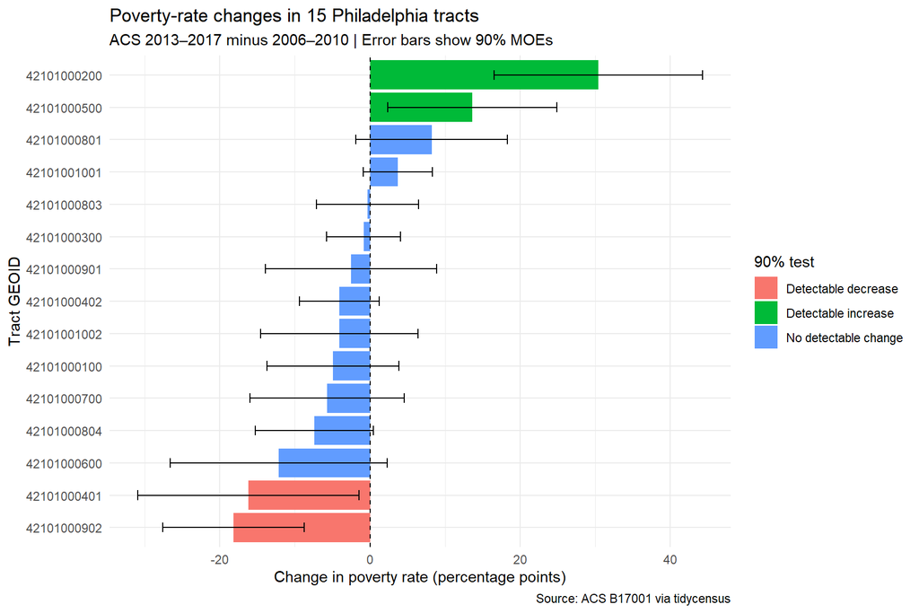

Figure 1: Estimated changes and 90% margins of error for the first 15 testable tract GEOIDs in ascending order. This is an illustrative subset, not a neighborhood grouping or a ranking of changes.

```r
plot_tracts <- poverty_tested %>%
  filter(!is.na(significant)) %>%
  arrange(GEOID) %>%
  slice_head(n = 15)

ggplot(plot_tracts, aes(x = reorder(GEOID, change), y = change)) +
  geom_col(aes(fill = result)) +
  geom_errorbar(
    aes(ymin = change - moe_diff, ymax = change + moe_diff),
    width = 0.3
  ) +
  geom_hline(yintercept = 0, linetype = "dashed") +
  coord_flip() +
  theme_minimal() +
  labs(
    title = "Poverty-rate changes in 15 Philadelphia tracts",
    subtitle = "ACS 2013–2017 minus 2006–2010 | Error bars show 90% MOEs",
    x = "Tract GEOID", y = "Change in poverty rate (percentage points)",
    fill = "90% test", caption = "Source: ACS B17001 via tidycensus"
  )
```

The dashed line marks zero change. An error bar crossing this line means that the estimated change is not statistically detectable. Bars above zero are estimated increases; those below zero are estimated decreases. The chart keeps both detectable and non-detectable changes so the reader can compare them.

### Reliability of the rates

The CV is the rate’s standard error divided by its estimate, multiplied by 100. I use the assignment’s thresholds: **below 12% reliable, 12–40% somewhat reliable, and above 40% unreliable**. Exactly 40% is therefore somewhat reliable. The symbols below provide the required coding without relying on color alone. The table highlights the 15 tract-period estimates with the highest defined CVs; it is not a summary of the typical tract.

```r
poverty_rates %>%
  filter(!is.na(cv)) %>%
  arrange(desc(cv)) %>%
  slice_head(n = 15) %>%
  select(GEOID, period, pov_rate, pov_rate_moe, cv, reliability) %>%
  gt() %>%
  fmt_number(columns = c(pov_rate, pov_rate_moe, cv), decimals = 1) %>%
  cols_label(
    GEOID = "Tract GEOID", period = "ACS period",
    pov_rate = "Poverty rate (%)", pov_rate_moe = "90% MOE (pp)",
    cv = "CV (%)", reliability = "Reliability"
  ) %>%
  cols_align(align = "center") %>%
  tab_header(
    title = "Philadelphia poverty rates with the highest relative uncertainty",
    subtitle = "15 tract-period estimates | ACS 2006–2010 and 2013–2017"
  )
```

Philadelphia poverty rates with the highest relative uncertainty

15 tract-period estimates | ACS 2006–2010 and 2013–2017

| Tract GEOID | ACS period | Poverty rate (%) | 90% MOE (pp) | CV (%) | Reliability |
| --- | --- | --- | --- | --- | --- |
| 42101989100 | 2013-2017 | 92.5 | 220.4 | 144.9 | Unreliable |
| 42101980000 | 2013-2017 | 4.9 | 7.0 | 85.6 | Unreliable |
| 42101980600 | 2006-2010 | 9.8 | 13.8 | 85.5 | Unreliable |
| 42101023500 | 2006-2010 | 4.8 | 5.6 | 71.6 | Unreliable |
| 42101023600 | 2006-2010 | 9.9 | 11.5 | 70.8 | Unreliable |
| 42101001001 | 2006-2010 | 2.2 | 2.5 | 70.4 | Unreliable |
| 42101036600 | 2006-2010 | 2.9 | 3.3 | 68.1 | Unreliable |
| 42101023100 | 2013-2017 | 0.8 | 0.8 | 66.7 | Unreliable |
| 42101034801 | 2006-2010 | 10.3 | 11.2 | 66.4 | Unreliable |
| 42101025600 | 2013-2017 | 3.6 | 3.9 | 64.7 | Unreliable |
| 42101980200 | 2006-2010 | 22.2 | 23.0 | 63.2 | Unreliable |
| 42101001500 | 2006-2010 | 7.4 | 7.5 | 62.0 | Unreliable |
| 42101980100 | 2013-2017 | 13.3 | 13.4 | 61.5 | Unreliable |
| 42101038500 | 2006-2010 | 7.2 | 7.0 | 59.6 | Unreliable |
| 42101038600 | 2013-2017 | 3.0 | 3.0 | 59.3 | Unreliable |

Some margins of error are large relative to the rate itself. I retain uncertain but calculable estimates in the change test because removing them would hide part of the evidence. A large MOE widens the change interval and makes a detectable result harder to establish.

### Put the illustrated changes in context

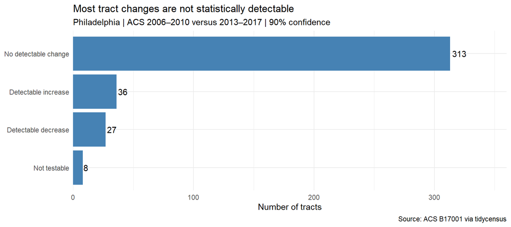

Figure 2: Counts include all downloaded tract GEOIDs. Not testable is kept separate from no detectable change.

```r
ggplot(change_counts, aes(x = reorder(result, tracts), y = tracts)) +
  geom_col(fill = "steelblue") +
  geom_text(aes(label = tracts), hjust = -0.15) +
  scale_y_continuous(expand = expansion(mult = c(0, 0.15))) +
  coord_flip() +
  theme_minimal() +
  labs(
    title = "Most tract changes are not statistically detectable",
    subtitle = "Philadelphia | ACS 2006–2010 versus 2013–2017 | 90% confidence",
    x = NULL, y = "Number of tracts",
    caption = "Source: ACS B17001 via tidycensus"
  )
```

The full count provides context for the small error-bar sample. There are 211 positive point-estimate changes, but only 36 detectable increases. Looking only at the signs of the changes would overstate the evidence for rising poverty.

## Part 3 — Adjudicate

**Supported:** the broader idea that poverty rates increased in some Philadelphia areas is consistent with the tract evidence: 36 tracts have detectable increases. Change is not uniform, however; 27 tracts have detectable decreases. **Not supported:** interpreting every positive estimate as established worsening would go beyond the evidence. Of 211 positive changes, only 36 pass the 90% test, and 313 testable tracts overall have intervals that include zero. This is a limit on what can be inferred from the estimates, not evidence that the article explicitly claimed every tract worsened or that every non-detectable change is actually zero.

**Cannot be determined:** the specific claim that Eastwick rose from 12% to 26%, and especially that its increase was the largest among neighborhoods, cannot be established or contradicted by these tract results. The assignment says the article’s neighborhood groupings are unavailable. A neighborhood rate would require the appropriate aggregated counts and their uncertainty, not an average of tract percentages. A tract with an increase above 14 percentage points would not disprove Eastwick’s neighborhood ranking because tracts and neighborhoods are different units. This report also makes no finding about the article title’s racial comparisons: the two variables used here describe poverty for the full poverty universe, without a race breakdown.

## Part 4 — Rewrite

Philadelphia’s poverty changes were uneven between 2006–2010 and 2013–2017. Among 376 census tracts with usable estimates, 36 showed a statistically detectable increase in poverty rates and 27 showed a detectable decrease at 90% confidence. Changes in the other 313 tracts were too uncertain to distinguish from zero. Another 8 tracts could not be compared because their poverty rates were undefined in at least one period. These findings support increases in some parts of the city, but they do not establish Eastwick’s reported rise from 12% to 26% or its ranking among neighborhoods. Checking those claims requires the tract groupings used to define each neighborhood.